### Ejercicio 3

Consideremos una población con ley gamma de parámetros $r = 5$ y $\lambda = \dfrac{1}{4}$.

#### **(A)**

Lo que se tiene que hacer es simular muestras aleatorias de una distribución gamma, en nuestro caso, Gamma$(5, \frac{1}{4})$ y tomar la media en cada iteración. La gamma se define mediante dos parámetros, forma y escala, en nuestro caso:

- parámetro de forma: $5$
- parámetro de escala: $\dfrac{1}{4}$

Calcularemos la media de una distribución gamma $10^5$ veces con $n_i=200$, donde $n_i$ es el tamaño de cada muestra, $i=1,...,10^5$.

Si $X_1,X_2,...,X_n$ son muestras aleatorias de una ley gamma con forma $a$ y escala $b$, la suma $T=X_1+X_2+...+X_n$ es también una gamma con la misma escala pero con forma $an$. Por lo que, la distribución de la media muestral se aconsigue mediante la transformación: $(\bar{X})=T/n$ y tiene densidad $f_{\bar{X}}(x) = n f_T(nx)$.

Esto sigue una gamma con forma $an$ y escala $b/n$. Esto pasa ya que el valor esperado de una observación es $E(X_i) = ab$. La esperanza de su suma es $E(T)=abn$ y la esperanza de la media muestral es igual al valor esperado de una observación $X_i$:

$$E(\bar{X})=(an)(b/n)=ab.$$

Para la varianza no pasa lo mismo ya que esta depende del tamaño de la muestra, digamos $n$. Para una observación, Var$(X_i)=ab^2$, pero Var$(\bar{X})={(an)}{(b/n)^2} = \dfrac{ab^2}{n} \leq ab^2$, para $n \geq 1$.

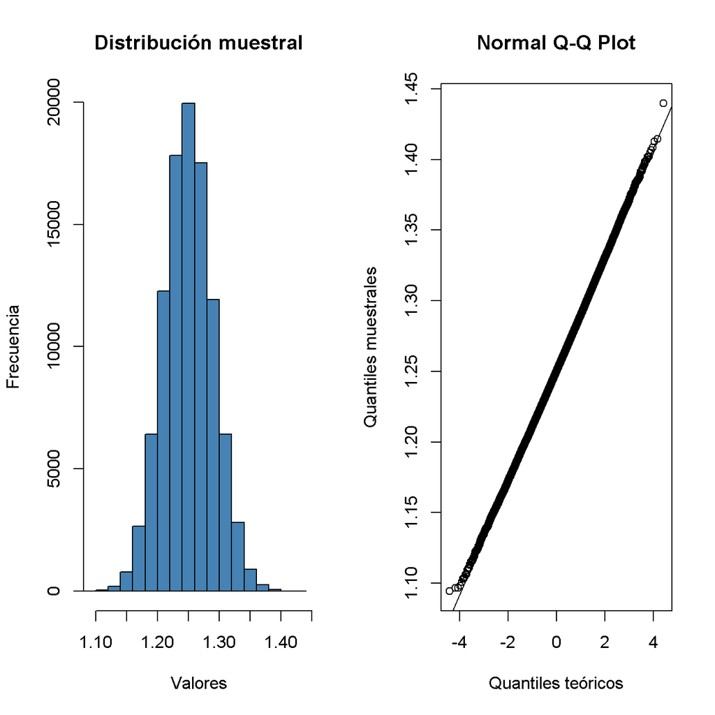

#### Análisis descriptivo distribución muestral

| Min. | 1.094 |
| --- | --- |
| 1st Qu. | 1.223 |
| Median | 1.25 |
| Mean | 1.25 |
| 3rd Qu. | 1.277 |
| Max. | 1.44 |
| Var | 0.0016 |

#### **(B)**

Generar una muestra aleatoria de tamaño 200 de la ley gamma. La línea vertical representa el valor de la media.

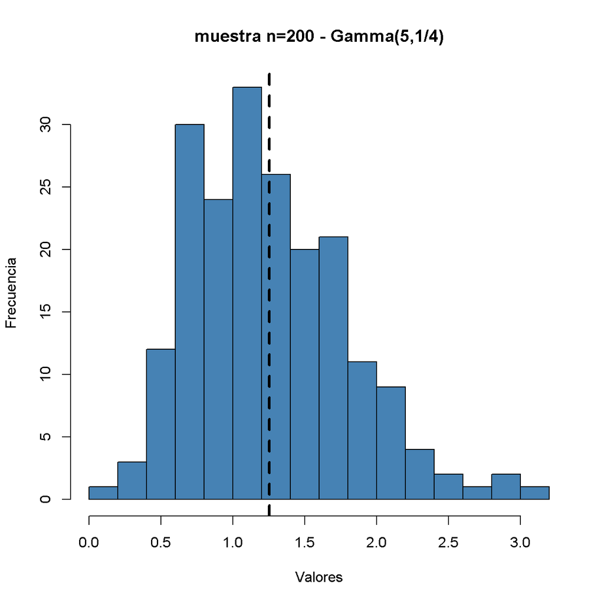

| Mean | 1.252 |
| --- | --- |
| SD | 0.540 |

#### **(C)**

```
Idea principal del bootstrap:
La muestra original aproxima a la población. Por lo que remuestras de esta muestra se aproximan a lo que
obtendríamos si tomaramos muchas muestras de la población. La distribución bootstrap de un estadístico, basada en muchas remuestras, se aproxima a la distribución de muestreo del estadístico, basado en muchas muestras.
```

Lo que me parece más interesante del bootstrap es que teniendo una muestra y suponiendo que es ‘representativa’ podemos obtener resultados fiables sin necesidad de obtener nuevas muestras, ya que eso en el mundo real, puede ser costoso o imposible de obtener. En este caso, podemos obtener la distribución bootstrap de la media muestral generando $m$ remuestras (muestras con reemplazo) de nuestra muestra de tamaño $n=200$ y en cada $m_i$ calcular el estadístico muestral, con $i=1,...,10^5$.

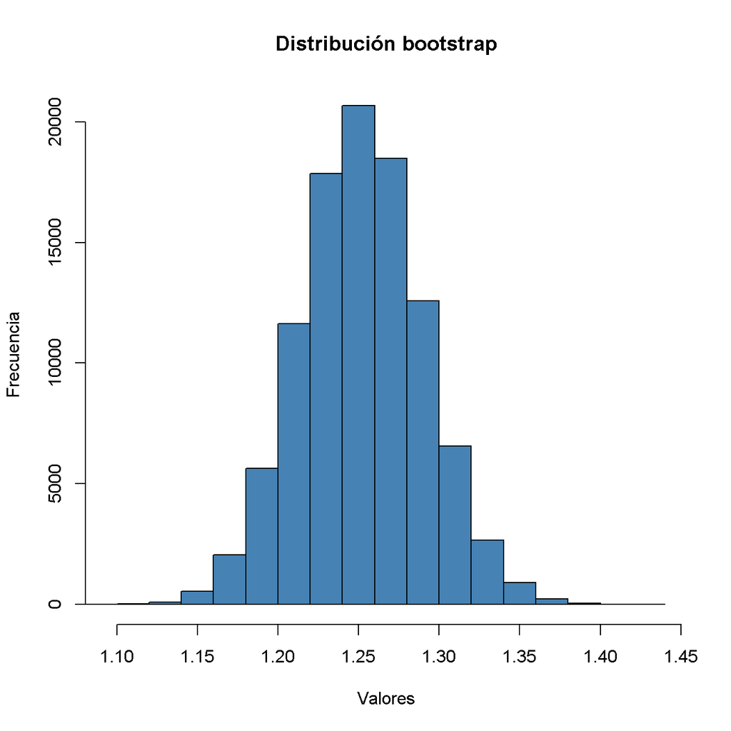

| Bootstrap mean | 1.252 |
| --- | --- |
| Standard error | 0.038 |

#### **(D)**

Ahora podemos comparar el resultado obtenido mediante bootstrap con la distribución muestral aproximada teórica (con $n=200$). Vemos que la distribución bootstrap es muy parecida a la distribución muestral aproximada. Se refleja que la esperanza es igual a la ley gamma poblacional, pero que la desviación decrece en función del tamaño de la muestra. Este resultado también demuestra que con remuestras de una sola muestra (*muestras permutadas con reemplazamiento*) obtenemos resultados muy iguales a los obtenidos con $10^5$ muestras.

|  | Mean | SD |
| --- | --- | --- |
| Población | 1.2500 | 0.5590 |
| Distribución muestral aproximada de la media (n=200) | 1.2502 | 0.0395 |
| Muestra n=200 | 1.2522 | 0.5397 |
| Distribución bootstrap (remuestras con n=200) | 1.2521 | 0.0380 |

#### Comparación mediante gráficos

Las líneas verticales representan la media.

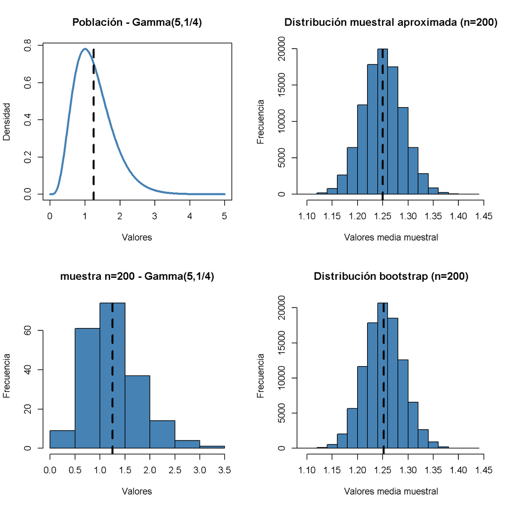

#### **(E)**

El problema del bootstrap, es que si cogemos datos no representativos de la población que queremos **dibujar** (por ejemplo, en este caso, una muestra pequeña), los resultados pueden aproximar el estadístico muestral con sesgo. Para $n=10$, la estimación es sesgada, por lo que los errores son más grandes, error que hará los intervalos bootstrap menos precisos y fiables. La línea vertical representa la media muestral.

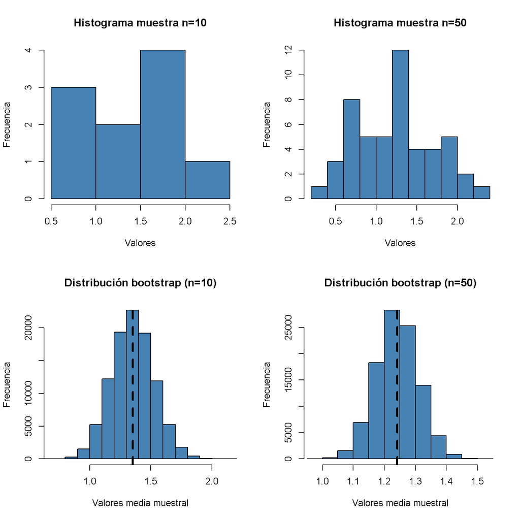

```
--------boot10--------
```

```
Mean = 1.351181
```

```
Intervalo para la media muestral
```

```
    2.5%    97.5%
1.020112 1.693709
```

```
--------boot50--------
```

```
Mean = 1.24153
```

```
Intervalo para la media muestral
```

```
    2.5%    97.5%
1.109372 1.374697
```

```
--------boot200--------
```

```
Mean = 1.252087
```

```
Intervalo para la media muestral
```

```
    2.5%    97.5%
1.178679 1.327445
```